# Ocean silicate: ordinal oxygen and partial exact measurements

The application models silicate using salinity, log pressure and oxygen. Oxygen is recorded in four bands, with exact measurements available for 0%, 20% or 50% of the training profiles. The same frozen cohort, five folds and nested observation masks are used throughout.

## 1. Select the computation

Choose `action="plan"` to inspect the selected work, `"run"` to fit or resume, and `"report"` to read completed fits. `folds`, `cells` and `modules` select work without changing numerical settings or seeds. Use separate result roots for distributed jobs and `import_dirs` to merge compatible completed tasks. Runnable examples and all selectors are in `codes/applications/ocean_silicate/README.md`.

**Profile:** paper; **action:** report; **folds:** 1, 2, 3, 4, 5; **training calibration:** 0%, 20%, 50%.

Selected work: **50 base tasks** and **15 conditional continuation candidates**.

Paper fits use four chains of 20,000 iterations, burn-in 5,000 and `u_block_size=8`. A cell receives one additional 20,000 iterations when its initial maximum finite Rhat exceeds 1.01, minimum finite bulk ESS is below 400, or no finite values are available. Undefined diagnostics and tail ESS are recorded for inspection. The fitting overview below combines availability, continuation and final screening in one row per fold. The `quick` profile uses fold 1/O0/O50 and one 80-iteration chain as a workflow check.

## 2. Explore the observed data

The frozen subset contains 200 distinct profiles. Each fold has 160 training and 40 held-out profiles. Recorded oxygen is retained for offline checking; only the calibration-mask entries enter the model as exact U.

```r
cohort <- inputs$cohort
levels(cohort$oxygen_class) <- c("<50","50-100","100-150","150-180")
knitr::kable(as.data.frame(table(cohort$oxygen_class)),
  col.names=c("Oxygen class (micromol/kg)","Observations"))
```

| Oxygen class (micromol/kg) | Observations |
| --- | --- |
| <50 | 50 |
| 50-100 | 50 |
| 100-150 | 50 |
| 150-180 | 50 |

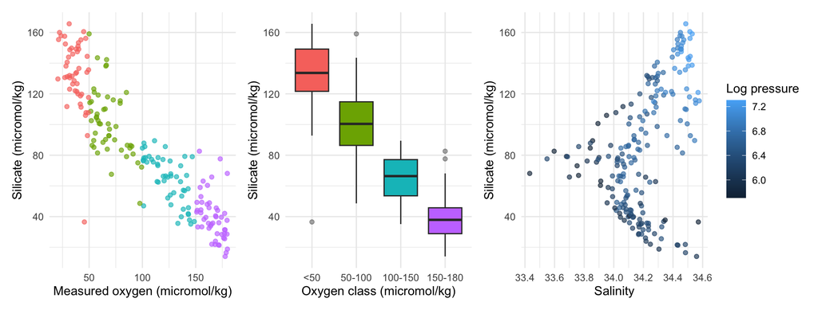

```r
library(ggplot2)
library(patchwork)
p1 <- ggplot(cohort,aes(U,Y,color=oxygen_class))+geom_point(alpha=.65)+
  labs(x="Measured oxygen (micromol/kg)",y="Silicate (micromol/kg)",color="Oxygen class")+
  theme_minimal()+theme(legend.position="none")
p2 <- ggplot(cohort,aes(oxygen_class,Y,fill=oxygen_class))+geom_boxplot(outlier.alpha=.4)+
  labs(x="Oxygen class (micromol/kg)",y="Silicate (micromol/kg)")+
  theme_minimal()+theme(legend.position="none")
p3 <- ggplot(cohort,aes(G2salinity,Y,color=log_pressure))+geom_point(alpha=.65)+
  labs(x="Salinity",y="Silicate (micromol/kg)",color="Log pressure")+theme_minimal()
p1+p2+p3
```

## 3. Fit the models and make held-out predictions

The chunk below is the workflow entry point. With `action="run"`, it fits selected tasks or reuses verified completed tasks, checks the initial chains, continues cells selected by those diagnostics, and saves held-out predictions. With `action="report"`, it reads completed results; with `action="plan"`, it returns the task plan.

```r
if (settings$action == "plan") {
  analysis <- ocean_execute(repository_dir, data_dir, output_dir, settings)
} else {
  analysis <- ocean_logged(
    file.path(output_dir, "jobs", settings$run_id, "execution.log"),
    ocean_execute(
      repository_dir, data_dir, output_dir, settings,
      import_dirs = import_dirs,
      augmented_output_dir = augmented_output_dir
    )
  )
}
```

`01_setup.R` assigns the selected tasks to the fitting functions in `02_fit_models.R`. For each EIV task, `run_eiv()` prepares X, C and U_obs, calls `eivGP::fit_eivgp()`, then `eivGP::predict_eivgp()` and `eivGP::impute_eivgp()`. X contains salinity and log pressure; C contains the recorded oxygen class; U_obs contains calibration measurements and NA elsewhere. Selected continuations call `eivGP::continue_eivgp()` and update predictions and imputation from the continued fit.

Baseline tasks call the pinned adapter `eivGP:::run_published_mixedgp_competitors()`, which uses `kergp::gp()`, `LVGP::LVGP_fit()` or `EzGP::EzGP_fit()` and their native predictors. Unstarred methods use (x,c). Starred methods add categorical observation status R and continuous oxygen record W; observed W uses the training calibration mean/SD, and hidden W takes placeholder 0. Native kernels and fitting procedures are used for both representations.

| Fold | 0% exact U | 20% exact U | 50% exact U |
| --- | --- | --- | --- |
| 1 | +20k; pass | Initial; pass | Initial; pass |
| 2 | Initial; pass | Initial; pass | Initial; pass |
| 3 | Initial; pass | +20k; pass | Initial; pass |
| 4 | +20k; pass | Initial; pass | Initial; pass |
| 5 | Initial; pass | Initial; pass | Initial; pass |

Initial / +20k identifies the saved fit used in the report. Pass refers to the prespecified finite-Rhat/bulk-ESS screen; full chain diagnostics remain in the result files.

## 4. Inspect held-out silicate predictions

The fitting module saves held-out predictions from `predict_eivgp()`, together with posterior-state IDs and seeds for each initial or continued fit. The table below summarizes those saved predictions.

Class-only testing supplies no exact test oxygen. Mixed testing reveals 20% or 50% under the same saved masks to EIV-GP and the starred baselines. At those rows, EIV-GP uses `new_U` and `new_U_scale="raw"`; other rows keep class-only predictions. All held-out responses are excluded from fitting and tuning.

### Silicate prediction

Entries are fold means (sample SDs). RMSE is in micromol/kg; sY is the frozen cohort response SD. * marks UC-GP, LVGP and EzGP with the same recorded training/test oxygen measurements as EIV-GP. Incomplete groups state their fold count in the method label.

Silicate prediction under matched oxygen information

| Method | RMSE | CRPS / sY | Coverage (%) | Width / sY |
| --- | --- | --- | --- | --- |
| A. 0% exact training oxygen; test: Class only |  |  |  |  |
| UC-GP | 13.82 (4.22) | 0.178 (0.027) | 96.0 (2.2) | 1.334 (0.113) |
| LVGP | 11.02 (1.10) | 0.146 (0.006) | 94.5 (2.1) | 0.992 (0.062) |
| EzGP | **10.85** (2.12) | 0.144 (0.018) | 93.0 (3.3) | 0.854 (0.011) |
| EIV-GP | 11.04 (1.63) | **0.139** (0.009) | 94.0 (2.9) | 0.981 (0.064) |
| B. 20% exact training oxygen |  |  |  |  |
| Test oxygen: Class only |  |  |  |  |
| UC-GP* | 14.60 (4.55) | 0.184 (0.037) | 93.0 (3.3) | 1.185 (0.216) |
| LVGP* | 11.12 (0.98) | 0.146 (0.008) | 92.5 (1.8) | 0.987 (0.063) |
| EzGP* | 11.38 (1.96) | 0.155 (0.015) | 94.5 (4.8) | 1.026 (0.331) |
| EIV-GP | **10.77** (1.43) | **0.137** (0.010) | 96.0 (2.2) | 1.006 (0.086) |
| Test oxygen: 20% exact |  |  |  |  |
| UC-GP* | 14.60 (4.55) | 0.184 (0.037) | 93.0 (3.3) | 1.186 (0.217) |
| LVGP* | 11.15 (1.01) | 0.147 (0.008) | 93.0 (1.1) | 0.991 (0.066) |
| EzGP* | 11.63 (1.63) | 0.156 (0.014) | 94.5 (4.1) | 1.047 (0.330) |
| EIV-GP | **9.54** (1.00) | **0.125** (0.008) | 96.5 (2.9) | 0.945 (0.093) |
| C. 50% exact training oxygen |  |  |  |  |
| Test oxygen: Class only |  |  |  |  |
| UC-GP* | 14.48 (4.31) | 0.193 (0.043) | 95.0 (4.0) | 1.395 (0.278) |
| LVGP* | 11.59 (2.45) | 0.155 (0.019) | 91.0 (2.9) | 0.920 (0.041) |
| EzGP* | 11.34 (2.32) | 0.155 (0.020) | 89.0 (1.4) | 0.877 (0.017) |
| EIV-GP | **10.71** (1.47) | **0.138** (0.012) | 96.0 (3.4) | 1.136 (0.094) |
| Test oxygen: 50% exact |  |  |  |  |
| UC-GP* | 14.48 (4.31) | 0.193 (0.043) | 95.0 (4.0) | 1.396 (0.284) |
| LVGP* | 11.17 (2.07) | 0.146 (0.013) | 91.5 (1.4) | 0.924 (0.033) |
| EzGP* | 11.03 (2.24) | 0.145 (0.017) | 90.5 (2.1) | 0.890 (0.010) |
| EIV-GP | **9.11** (1.11) | **0.118** (0.006) | 94.5 (4.1) | 0.896 (0.079) |

Bold marks the smallest RMSE and CRPS mean within each complete five-fold information block, using unrounded values. Coverage and width are descriptive.

**Starred methods:** UC-GP*, LVGP* and EzGP* receive the same available exact oxygen values as EIV-GP through the (x,c,R,W) encoding described above. The primary placeholder is 0. At O0, unstarred methods use (x,c). Entries are fold means with sample SDs; fold SD describes variation across the overlapping training sets. CSV, Markdown, LaTeX and HTML tables are exported beside the unrounded scores.

## 5. Inspect oxygen imputation and response functions

The following components use the final EIV fits. Full displays require all five original baseline groups, all EIV cells and their selected continuations. Nearby measured profiles are shown once with the m/f fits.

### Training oxygen imputation

O20/O50 are scored on the same 80 hidden training rows per fold using bias, RMSE, MAE, 95% coverage and interval width. Hollow points are measured calibration inputs; solid points and intervals summarize masked-input posteriors. O0 remains on its unanchored model coordinate.

Training oxygen imputation

| Calibration | Bias | RMSE | MAE | Coverage (%) | Width |
| --- | --- | --- | --- | --- | --- |
| 20% | -0.39 (1.21) | 16.06 (1.65) | 11.27 (0.49) | 93.5 (2.2) | 53.87 (2.17) |
| 50% | **-0.31** (1.06) | **14.94** (1.57) | **10.32** (0.69) | 92.8 (1.6) | 50.40 (1.06) |

Entries are five-fold means (sample SDs), computed on the same 80 masked training profiles per fold. Bias, RMSE, MAE and width are in micromol/kg; coverage is percent for individual-U 95% posterior intervals. Bold marks the smaller absolute mean bias, RMSE and MAE across calibration levels for the same target group, using unrounded values. Coverage and width are descriptive.

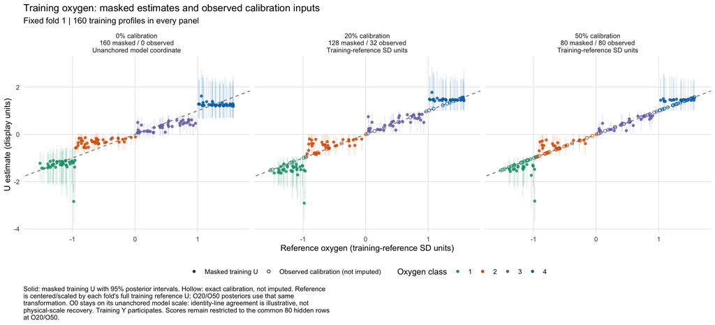

### Category means m(x,c)

Category means integrate the fitted response over the conditional oxygen distribution. The pressure slice fixes salinity at 34.20. The comparison uses the three original (x,c) baselines; their category predictors target m directly. EIV O0 uses class-only training information, and O20/O50 show the calibrated fits.

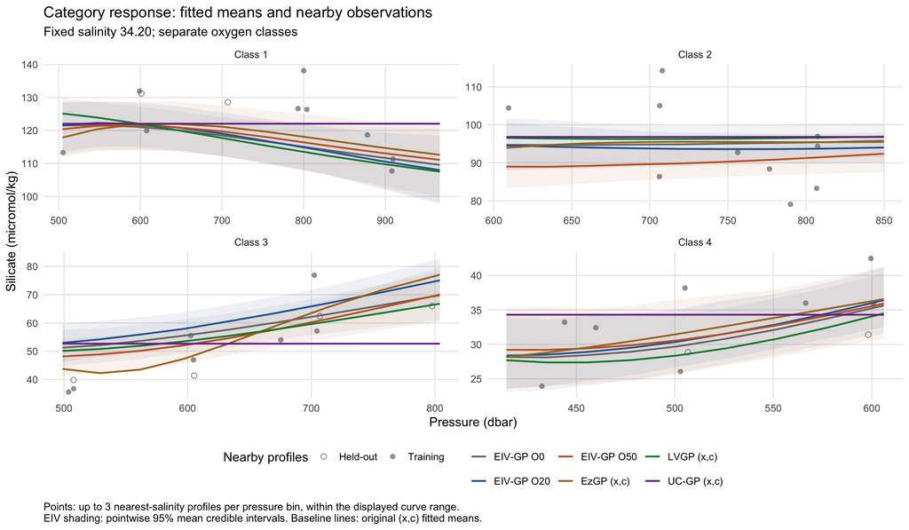

Points are measured silicate in the local salinity pool, balanced over six log-pressure bins with at most three nearest-salinity profiles per bin. Filled and hollow points identify training and held-out profiles. Selection uses inputs only; these noisy responses provide context for the fitted means.

### Continuous response f(x,u)

The continuous slice fixes salinity at 34.25 and pressure at 650 dbar, then varies oxygen. It uses O20/O50 fits on the physical oxygen scale. The grid follows the central oxygen range of nearby reference profiles.

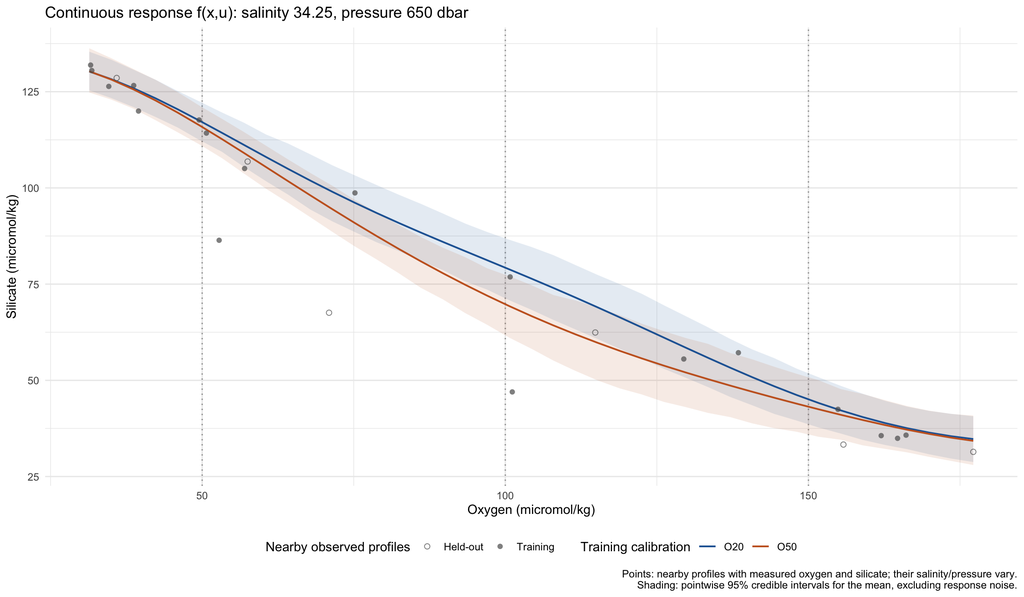

The measured profiles have nearby, varying salinity and pressure, and their responses include noise. Shading in both m/f plots represents pointwise 95% credible intervals for the mean, including conditional GP uncertainty. It excludes response noise. True m/f values are unavailable in this semi-real application, so these displays are not surface-recovery scores.

### Supplement: separate fitted folds

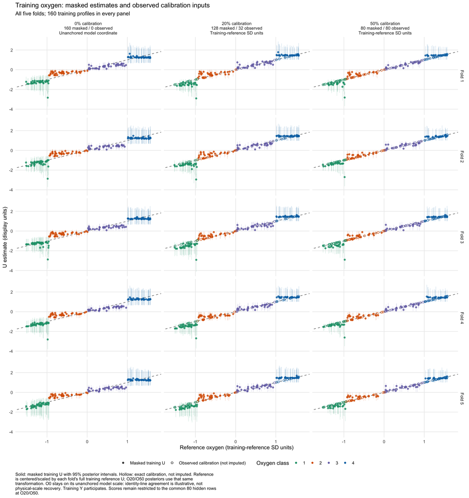

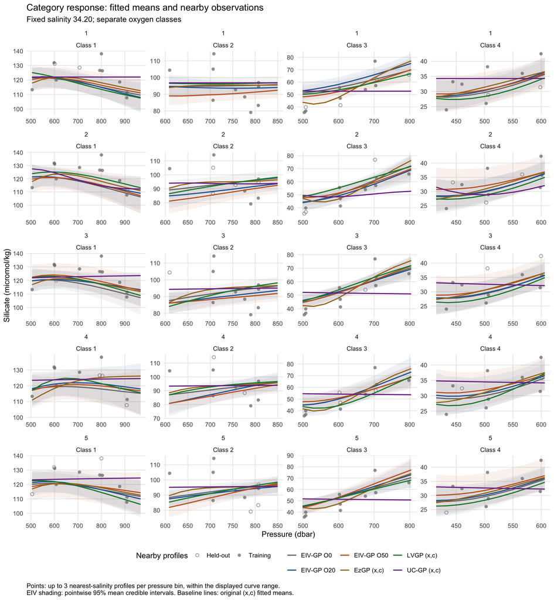

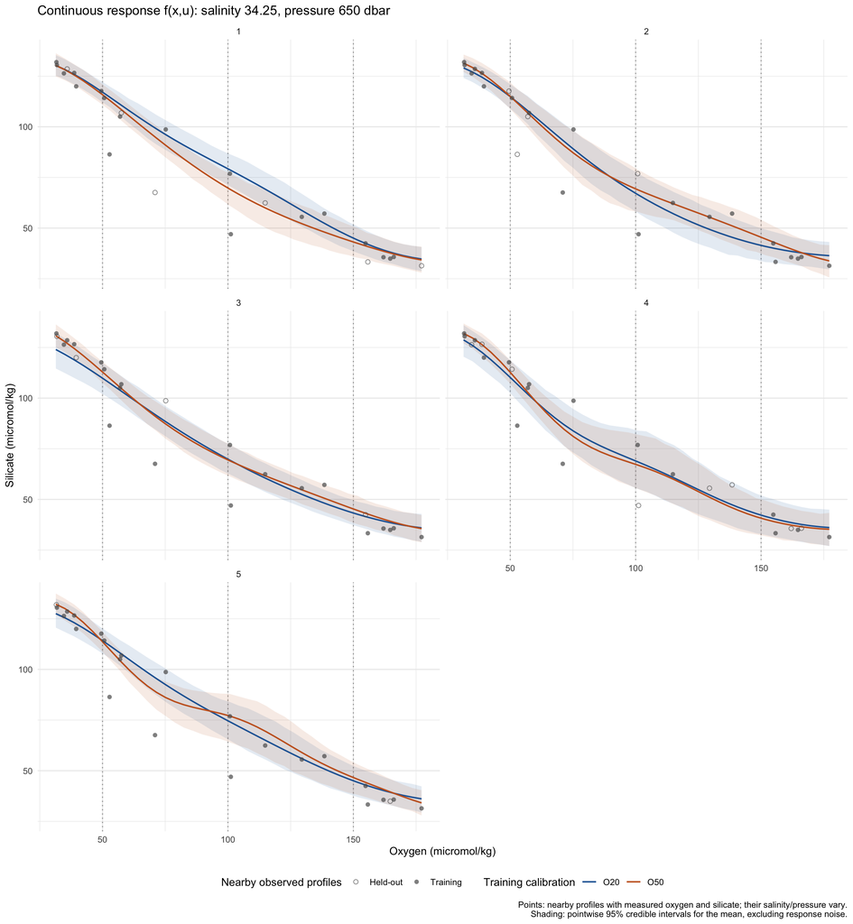

Training oxygen imputation by class

| Calibration | Class | Bias | RMSE | MAE | Coverage (%) | Width |
| --- | --- | --- | --- | --- | --- | --- |
| 20% | 1 | -16.86 (2.52) | 24.07 (4.93) | 16.96 (2.50) | 98.0 (2.7) | 71.06 (5.42) |
| 20% | 2 | 8.59 (1.74) | 14.04 (2.34) | 10.79 (2.07) | 83.0 (5.7) | 37.67 (2.66) |
| 20% | 3 | -0.82 (0.93) | 10.17 (1.20) | 7.91 (1.03) | 93.0 (4.5) | 34.67 (3.72) |
| 20% | 4 | 7.52 (0.84) | 11.61 (0.53) | 9.43 (0.22) | 100.0 (0.0) | 72.07 (1.84) |
| 50% | 1 | **-14.32** (2.97) | **22.06** (4.70) | **14.55** (2.94) | 93.0 (4.5) | 62.93 (3.93) |
| 50% | 2 | **7.36** (1.55) | **13.38** (1.69) | **10.46** (1.61) | 84.0 (8.2) | 37.68 (1.31) |
| 50% | 3 | **-0.57** (1.39) | **10.00** (1.48) | **7.64** (1.14) | 94.0 (4.2) | 33.78 (1.61) |
| 50% | 4 | **6.27** (1.10) | **10.61** (0.70) | **8.61** (0.57) | 100.0 (0.0) | 67.22 (2.15) |

Entries are five-fold means (sample SDs), computed on the same 80 masked training profiles per fold. Bias, RMSE, MAE and width are in micromol/kg; coverage is percent for individual-U 95% posterior intervals. Bold marks the smaller absolute mean bias, RMSE and MAE across calibration levels for the same target group, using unrounded values. Coverage and width are descriptive.

## 6. Reproduce and cite

Seeds are independent of work assignment and execution order. Completed-task receipts validate reuse and merging. Full diagnostics and logs are stored under the result root; `jobs/<run_id>/` contains execution logs. The HTML embeds its figures. Data provenance and environment requirements are in `codes/applications/ocean_silicate/README.md`.

Data: GLODAPv2.2023 merged and adjusted product, DOI **10.25921/zyrq-ht66**. Product reference: Lauvset et al. (2024), *Earth System Science Data* 16, 2047–2072, DOI **10.5194/essd-16-2047-2024**.

| R | profile | action |
| --- | --- | --- |
| 4.5.1 | paper | report |